# midterm_prep

Exam policy

1. Setting your vscode, python, and jupyternotebook environment as guided below(10):
- If you fail to create the environment having error, then you can request a help to TA and instructor, but you will get -5 score. a. You will create new project called "midterm_yourname" b. You will create virtual environment in your vscode. c. You will set your jupyternotebook kernel(engine) d. You will install all required python libraries using 'pip install'
1. Solving problems

```python
import numpy as np
import pandas as pd
import matplotlib as map
import matplotlib.pyplot as plt
import scipy as sc
import statistics as stat
from scipy.stats import binom
import seaborn as sns
```

HINTs: binom.pmf(x,n,p) np.arnage() plt.bar(x,y) plt.show() stat.NormalDist(mu=m, sigma=sd) NormalDist_object.cdf() NormalDist_object.inv_cdf() pd.read_csv() pandas_dataframe_object.sample() pandas_dataframe_object["column_name"].mean()

Question1.

Dongkyu and Chulung are working on an algorithmic trading project for the TEK club. By using their project, Dongkyu assumes that their project has 60% chance of making a profitable trade (success) and 40% chance of making an unprofitable trade (failure) in the stock market.

1. What is the probability of making 15 profitable trades out of 20 with a given successful rate?
2. Draw a probability distribution plot of this case.

```python
n=20
p=0.6
x=15
binom_pmf_single=binom.pmf(x,n,p)
binom_pmf_single
```

```
0.07464701952887114
```

```python
k=np.arange(0,n+1)
k
```

```
array([ 0,  1,  2,  3,  4,  5,  6,  7,  8,  9, 10, 11, 12, 13, 14, 15, 16,
       17, 18, 19, 20])
```

```python
binomial_pmf_all=binom.pmf(k,n,p)
binomial_pmf_all
```

```
array([1.09951163e-08, 3.29853488e-07, 4.70041221e-06, 4.23037099e-05,
       2.69686150e-04, 1.29449352e-03, 4.85435071e-03, 1.45630521e-02,
       3.54974396e-02, 7.09948791e-02, 1.17141551e-01, 1.59738478e-01,
       1.79705788e-01, 1.65882266e-01, 1.24411699e-01, 7.46470195e-02,
       3.49907904e-02, 1.23496907e-02, 3.08742268e-03, 4.87487792e-04,
       3.65615844e-05])
```

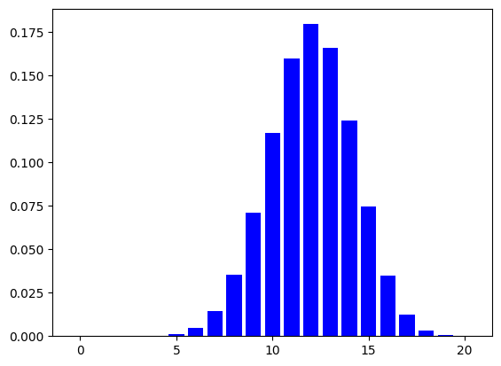

```python
plt.bar(k, binomial_pmf_all, color='blue')
plt.show()
```

Question2.

Jiwon, Juah, and Hyeonji take a multiple-choice exam together. Each question has two possible answers (True or False). As they work together to solve each question, their probability of guessing the correct answer is 70%.

Question3.

Hyundai motor company produces new electric vehicle. This new vehicle has a battery pack and its average lifetime was 400,000km and standard deviation was 40,000km. Then, the Hyundai wants to provide a new promotion replacing battery pack for free if it doesn't last equal or more than 100,000km. So, they want to know the probability that the battery will fail to last equal or more than 100,000km.

```python
m=400000
sd=40000
x=100000
nmdist=stat.NormalDist(mu=m, sigma=sd)
nmdist.cdf(x)
```

```
3.191891195797325e-14
```

Question4.

Hyundai motor company does not want to provide free replacement service more than 10% of its sold electric vehicles. Then, how much of km do they need to guarantee?

```python
m=400000
sd=40000
p=0.1
nmdist.inv_cdf(p)
```

```
348737.93737821595
```

Question5.

Incheon city administrator wanted to measure average amount of daily water intake of adults living in Songdo area for this year 2023. They collected list of all adult residents in Songdo and surveyed their daily water intake.

1. What is population here? Adults living in Songdo area for the year 2023.
2. What is parameter here? Average amount of daily water intake of adults living in Songdo area for the year 2023
3. Load the data table into your python environment.
4. Do the random sampling as much as 10% of its observations.
5. Calculate your sample statistics.

```python
df=pd.read_csv("water.csv")
df
```

|  | Unnamed: 0 | wt_day |
| --- | --- | --- |
| 0 | 0 | 2.304494 |
| 1 | 1 | 3.115432 |
| 2 | 2 | 2.709209 |
| 3 | 3 | 2.295899 |
| 4 | 4 | 2.483021 |
| ... | ... | ... |
| 89995 | 89995 | 2.236171 |
| 89996 | 89996 | 2.777696 |
| 89997 | 89997 | 2.572248 |
| 89998 | 89998 | 2.019097 |
| 89999 | 89999 | 2.392465 |

90000 rows × 2 columns

```python
df_sam=df.sample(frac=0.1)
df_sam
```

|  | Unnamed: 0 | wt_day |
| --- | --- | --- |
| 51339 | 51339 | 3.335108 |
| 25703 | 25703 | 2.732767 |
| 28807 | 28807 | 2.814780 |
| 61845 | 61845 | 2.547129 |
| 17953 | 17953 | 2.477580 |
| ... | ... | ... |
| 53351 | 53351 | 2.065639 |
| 79290 | 79290 | 2.363218 |
| 87177 | 87177 | 2.462122 |
| 66998 | 66998 | 3.153484 |
| 42741 | 42741 | 2.442149 |

9000 rows × 2 columns

```python
df_sam["wt_day"].mean()
```

```
2.496973202563832
```